# Efficacy of the Unified Protocol for Emotional Disorders

> **Project:**  
> To test the efficacy of the Unified Protocol, a transdiagnostic intervention for emotional disorders, a randomized controlled study was conducted. Interested participants who met the inclusion criteria were randomly assigned to either the treatment group or the control group (waitlist). Both groups were assessed at three different time points: before starting treatment, at five weeks, and at the end of treatment. The measured variables were depression (using the BDI), anxiety (using the BAI), and emotional dysregulation (using the DERS).  
> To determine whether the intervention had positive effects on patients, a mixed-effects model was employed. In this model, time and group variables were included as fixed effects, while patients and items were considered random effects. The analysis focused on comparing the slopes of the different groups and evaluating the interaction between time and treatment condition.

# Workspace preparation

## Libraries

```r
options(scipen = 999) # para que solo aparezcan 3 decimales
library(readxl)
library(tidyverse)
library(lme4)
library(lmerTest)
library(emmeans)
library(parameters)
library(sjPlot)
```

## Dataset

```r
BasePU <- read_xlsx("df_GruposPU.xlsx")
```

## I create a long-format dataset for each variable of interest.

##### Emotional Dysregulation

```r
DElong <-  select(BasePU, ID, Condition, Week, D1:D30)
DElong <- pivot_longer(DElong,
             cols = D1:D30,
               names_to = "item",
               values_to = "rating")
DElong$ID <- as.factor(DElong$ID)
summary(DElong)
```

```
##         ID        Condition              Week            item
##  2021_004:  90   Length:4050        Min.   : 0.000   Length:4050
##  2021_014:  90   Class :character   1st Qu.: 0.000   Class :character
##  2021_021:  90   Mode  :character   Median : 5.000   Mode  :character
##  2021_022:  90                      Mean   : 5.037
##  2021_027:  90                      3rd Qu.:10.000
##  2022_003:  90                      Max.   :11.000
##  (Other) :3510
##      rating
##  Min.   :1.00
##  1st Qu.:2.00
##  Median :2.00
##  Mean   :2.65
##  3rd Qu.:4.00
##  Max.   :5.00
##
```

##### Depresion

```r
BDIlong <-  select(BasePU, ID, Condition, Week, BDI1:BDI21)
BDIlong <- pivot_longer(BDIlong,
             cols = BDI1:BDI21,
               names_to = "item",
               values_to = "rating")
BDIlong$ID <- as.factor(BDIlong$ID)
summary(BDIlong)
```

```
##         ID        Condition              Week            item
##  2021_004:  63   Length:2835        Min.   : 0.000   Length:2835
##  2021_014:  63   Class :character   1st Qu.: 0.000   Class :character
##  2021_021:  63   Mode  :character   Median : 5.000   Mode  :character
##  2021_022:  63                      Mean   : 5.037
##  2021_027:  63                      3rd Qu.:10.000
##  2022_003:  63                      Max.   :11.000
##  (Other) :2457
##      rating
##  Min.   :0.0000
##  1st Qu.:0.0000
##  Median :1.0000
##  Mean   :0.9735
##  3rd Qu.:2.0000
##  Max.   :3.0000
##
```

##### Anxiety

```r
BAIlong <-  select(BasePU, ID, Condition, Week, BAI1:BAI21)
BAIlong <- pivot_longer(BAIlong,
             cols = BAI1:BAI21,
               names_to = "item",
               values_to = "rating")
BAIlong$ID <- as.factor(BAIlong$ID)
summary(BAIlong)
```

```
##         ID        Condition              Week            item
##  2021_004:  63   Length:2835        Min.   : 0.000   Length:2835
##  2021_014:  63   Class :character   1st Qu.: 0.000   Class :character
##  2021_021:  63   Mode  :character   Median : 5.000   Mode  :character
##  2021_022:  63                      Mean   : 5.037
##  2021_027:  63                      3rd Qu.:10.000
##  2022_003:  63                      Max.   :11.000
##  (Other) :2457
##      rating
##  Min.   :0.0000
##  1st Qu.:0.0000
##  Median :0.0000
##  Mean   :0.7534
##  3rd Qu.:1.0000
##  Max.   :3.0000
##
```

# Emotional Dysregulation

## Base model

We run the base model against which we will compare the model of interest. This model only includes the random effects.

```r
DEbase <- lmer(rating ~ (1|ID) + (1|item), data = DElong)
```

## Model with interaction of fixed effects.

```r
DEModel <- lmer(rating ~ Week * Condition + (1|ID) + (1|item), data = DElong)
summary(DEModel)
```

```
## Linear mixed model fit by REML. t-tests use Satterthwaite's method [
## lmerModLmerTest]
## Formula: rating ~ Week * Condition + (1 | ID) + (1 | item)
##    Data: DElong
##
## REML criterion at convergence: 12223.7
##
## Scaled residuals:
##      Min       1Q   Median       3Q      Max
## -3.02583 -0.70538 -0.06786  0.69551  2.97394
##
## Random effects:
##  Groups   Name        Variance Std.Dev.
##  ID       (Intercept) 0.2919   0.5403
##  item     (Intercept) 0.1510   0.3886
##  Residual             1.1262   1.0612
## Number of obs: 4050, groups:  ID, 46; item, 30
##
## Fixed effects:
##                      Estimate  Std. Error          df t value
## (Intercept)          3.082554    0.143299   73.289375  21.511
## Week                -0.023000    0.006127 3973.163462  -3.754
## ConditionTto        -0.152484    0.168572   49.903704  -0.905
## Week:ConditionTto   -0.082233    0.008145 3973.308183 -10.096
##                               Pr(>|t|)
## (Intercept)       < 0.0000000000000002 ***
## Week                          0.000177 ***
## ConditionTto                  0.370045
## Week:ConditionTto < 0.0000000000000002 ***
## ---
## Signif. codes:  0 '***' 0.001 '**' 0.01 '*' 0.05 '.' 0.1 ' ' 1
##
## Correlation of Fixed Effects:
##             (Intr) Week   CndtnT
## Week        -0.214
## ConditionTt -0.642  0.182
## Wek:CndtnTt  0.161 -0.752 -0.243
```

> **Random effects:** On average, the rating scores of a typical subject vary by ±0.54 points from the overall mean, due to differences between subjects. This indicates that there are differences in how different subjects rate, regardless of the item or week. Furthermore, the rating scores of a typical item vary on average by ±0.39 points from the overall mean, due to differences between items. This suggests that there are items that consistently receive higher or lower ratings.  
> **Fixed effects:** The main effect of the Treatment condition is not statistically significant (Estimate = -0.152484, p = 0.370), which suggests that at baseline (week 0), there is no significant difference between the treatment and control conditions in the ratings. This is important as it shows that both groups start with the same levels of emotional dysregulation.  
> **Interaction:** The interaction between Week and the Treatment condition (Week:ConditionTto) is significant (Estimate = -0.082233, p < 0.001). This suggests that the reduction in emotional dysregulation levels over time is more pronounced in the treatment group compared to the control group.

## Group comparison at the end of the treatment

```r
emDE_week10 <- emmeans(DEModel, pairwise ~ Condition | Week, at = list(Week = 10))
summary(emDE_week10)
```

```
## $emmeans
## Week = 10:
##  Condition emmean    SE  df asymp.LCL asymp.UCL
##  Ctrl        2.85 0.143 Inf      2.57      3.13
##  Tto         1.88 0.134 Inf      1.62      2.14
##
## Degrees-of-freedom method: asymptotic
## Confidence level used: 0.95
##
## $contrasts
## Week = 10:
##  contrast   estimate    SE  df z.ratio p.value
##  Ctrl - Tto    0.975 0.168 Inf   5.787  <.0001
##
## Degrees-of-freedom method: asymptotic
```

> The results of the analysis using adjusted marginal means (emmeans) for week 10 show a significant difference between the control and treatment groups. In week 10, the control group has an adjusted marginal mean of 2.85, while the treatment group has a mean of 1.88. This difference of 0.975 points is statistically significant (p < 0.001), suggesting that participants in the treatment group have significantly lower emotional dysregulation scores compared to those in the control group.

## Model comparison

```r
anova(DEbase, DEModel)
```

```
## Data: DElong
## Models:
## DEbase: rating ~ (1 | ID) + (1 | item)
## DEModel: rating ~ Week * Condition + (1 | ID) + (1 | item)
##         npar   AIC   BIC  logLik deviance  Chisq Df            Pr(>Chisq)
## DEbase     4 12601 12627 -6296.7    12593
## DEModel    7 12216 12260 -6101.1    12202 391.15  3 < 0.00000000000000022 ***
## ---
## Signif. codes:  0 '***' 0.001 '**' 0.01 '*' 0.05 '.' 0.1 ' ' 1
```

> The AIC and BIC are lower in the full model. This indicates a better model fit, considering the penalty for complexity. The full model (DEModel) fits the data better compared to the base model (DEbase).  
> The difference in fit between the models is statistically significant. The extremely low p-value indicates that the DEModel, which includes the fixed effects of week and condition with their interaction, provides a significantly better fit compared to the base model, which only includes random effects.

## Results and report

```r
tab_model(DEModel)
```

|  | rating |  |  |
| --- | --- | --- | --- |
| Predictors | Estimates | CI | p |
| (Intercept) | 3.08 | 2.80 – 3.36 | **<0.001** |
| Week | -0.02 | -0.04 – -0.01 | **<0.001** |
| Condition [Tto] | -0.15 | -0.48 – 0.18 | 0.366 |
| Week × Condition [Tto] | -0.08 | -0.10 – -0.07 | **<0.001** |
| Random Effects |  |  |  |
| σ<sup>2</sup> | 1.13 |  |  |
| τ<sub>00</sub> <sub>ID</sub> | 0.29 |  |  |
| τ<sub>00</sub> <sub>item</sub> | 0.15 |  |  |
| ICC | 0.28 |  |  |
| N <sub>ID</sub> | 46 |  |  |
| N <sub>item</sub> | 30 |  |  |
| Observations | 4050 |  |  |
| Marginal R<sup>2</sup> / Conditional R<sup>2</sup> | 0.109 / 0.360 |  |  |

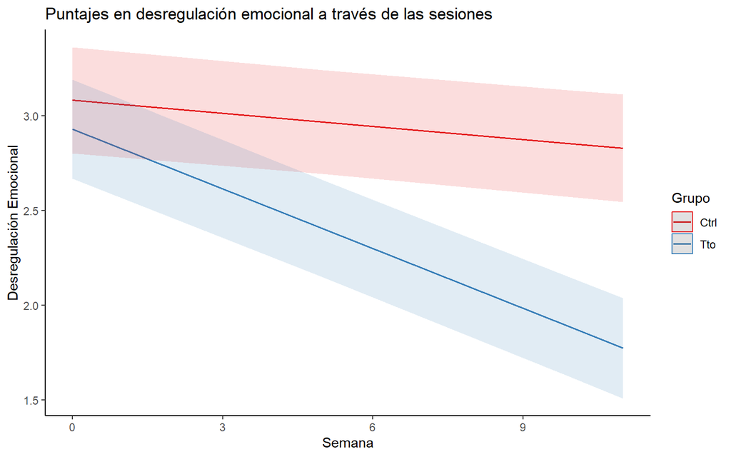

```r
plot_model(DEModel, type = "pred", terms = c("Week", "Condition")) +
  theme(axis.line = element_line(colour = "black"),
        panel.grid.major = element_blank(),
        panel.grid.minor = element_blank(),
        panel.border = element_blank(),
        panel.background = element_blank()) +
  ggtitle("Puntajes en desregulación emocional a través de las sesiones") +
  ylab("Desregulación Emocional") +
  xlab("Semana") +
  labs(colour = "Grupo")
```

> The comparison of models through maximum likelihood between a model with an interaction between weeks and group as fixed factors and random intercepts for participants and items, against a model that included only random factors, was significant (χ²(3)=391.15, p < .001). The model with only intercepts had higher fit indices (AIC = 12601, BIC = 12627) than the model with fixed factors (AIC = 12216, BIC = 12260).  
> In the model with fixed factors using Satterthwaite’s t estimation, it was observed that the groups started the study with the same level of emotional dysregulation (b = -0.15, SD = 0.17, t(49.90) = -0.91, p = 0.37). Then, when observing the interaction effect between time and group, a significant interaction was found where the participants in the treatment group had a significantly steeper slope (b = -0.08, SD = 0.008, t(3973.31) = -10.09, p < .001). In this model, 28% of the variance was explained by random factors, 10.9% by fixed factors, and 36% by the whole model.  
> Finally, when performing an analysis using adjusted marginal means (emmeans) for week 10, a significant difference was observed between the control and treatment groups. At the end of the treatment, the group treated with the PU showed significantly lower levels of emotional dysregulation (z = 5.79, 95% CI [0.65, 1.30], p < .001).

# Depresion

## Base model

We run the base model, which we will compare with the model of interest. This model only includes random effects.

```r
BDIbase <- lmer(rating ~ (1|ID) + (1|item), data = BDIlong)
```

## Model with fixed effects interaction

```r
BDIModel <- lmer(rating ~ Week * Condition + (1|ID) + (1|item), data = BDIlong)
summary(BDIModel)
```

```
## Linear mixed model fit by REML. t-tests use Satterthwaite's method [
## lmerModLmerTest]
## Formula: rating ~ Week * Condition + (1 | ID) + (1 | item)
##    Data: BDIlong
##
## REML criterion at convergence: 6519.2
##
## Scaled residuals:
##     Min      1Q  Median      3Q     Max
## -2.4424 -0.6694 -0.1232  0.5865  3.8458
##
## Random effects:
##  Groups   Name        Variance Std.Dev.
##  ID       (Intercept) 0.16353  0.4044
##  item     (Intercept) 0.03852  0.1963
##  Residual             0.54332  0.7371
## Number of obs: 2835, groups:  ID, 46; item, 21
##
## Fixed effects:
##                      Estimate  Std. Error          df t value
## (Intercept)          1.212742    0.103560   65.679060  11.711
## Week                -0.018095    0.005086 2766.726954  -3.558
## ConditionTto         0.006805    0.127616   50.692014   0.053
## Week:ConditionTto   -0.057317    0.006762 2766.851052  -8.477
##                               Pr(>|t|)
## (Intercept)       < 0.0000000000000002 ***
## Week                          0.000381 ***
## ConditionTto                  0.957684
## Week:ConditionTto < 0.0000000000000002 ***
## ---
## Signif. codes:  0 '***' 0.001 '**' 0.01 '*' 0.05 '.' 0.1 ' ' 1
##
## Correlation of Fixed Effects:
##             (Intr) Week   CndtnT
## Week        -0.246
## ConditionTt -0.673  0.199
## Wek:CndtnTt  0.185 -0.752 -0.266
```

> **Random effects:** On average, the depression scores of a typical subject vary by ±0.40 points from the overall mean, due to differences between subjects. This indicates individual variations in depression levels, independent of the item or week. Additionally, the scores of a typical item vary by ±0.20 points from the overall mean, suggesting that some items consistently receive higher or lower scores, showing differences in how the items capture depression.  
> **Fixed effects:** The main effect of the treatment condition is not statistically significant (Estimate = 0.006805, p = 0.958), suggesting that at baseline (week 0), there is no significant difference in depression levels between the treatment and control groups. This implies that both groups start the study with similar levels of depression, which is crucial for evaluating the treatment effect over time.  
> **Interaction:** The interaction between week and treatment condition is significant (Estimate = -0.057317, p < 0.001). This indicates that the reduction in depression levels over time is more pronounced in the treatment group compared to the control group. In other words, the treatment appears to be associated with a greater decrease in depression symptoms as time progresses.

## Group comparison at the end of the treatment

```r
emBDI_week10 <- emmeans(BDIModel, pairwise ~ Condition | Week, at = list(Week = 10))
summary(emBDI_week10)
```

```
## $emmeans
## Week = 10:
##  Condition emmean     SE   df lower.CL upper.CL
##  Ctrl       1.032 0.1040 66.0    0.825    1.239
##  Tto        0.465 0.0959 65.8    0.274    0.657
##
## Degrees-of-freedom method: kenward-roger
## Confidence level used: 0.95
##
## $contrasts
## Week = 10:
##  contrast   estimate    SE   df t.ratio p.value
##  Ctrl - Tto    0.566 0.128 50.9   4.442  <.0001
##
## Degrees-of-freedom method: kenward-roger
```

> The results of the analysis using adjusted marginal means (emmeans) for week 10 indicate a significant difference between the control and treatment groups. In week 10, the control group has an adjusted marginal mean of 1.03, while the treatment group has a mean of 0.47. This difference of 0.57 points is statistically significant (p < 0.001), suggesting that participants in the treatment group have significantly lower depression scores at the end of the treatment compared to those in the control group.

## Model comparison

```r
anova(BDIbase, BDIModel)
```

```
## Data: BDIlong
## Models:
## BDIbase: rating ~ (1 | ID) + (1 | item)
## BDIModel: rating ~ Week * Condition + (1 | ID) + (1 | item)
##          npar    AIC    BIC  logLik deviance  Chisq Df            Pr(>Chisq)
## BDIbase     4 6793.2 6817.0 -3392.6   6785.2
## BDIModel    7 6509.7 6551.4 -3247.9   6495.7 289.51  3 < 0.00000000000000022
##
## BDIbase
## BDIModel ***
## ---
## Signif. codes:  0 '***' 0.001 '**' 0.01 '*' 0.05 '.' 0.1 ' ' 1
```

> The AIC and BIC values are lower in the full model (BDIModel) compared to the base model (BDIbase), indicating a better fit for the full model when considering the penalty for complexity. This result suggests that the full model, which includes the fixed effects of Week and Condition, as well as their interaction, fits the data better. The inclusion of the fixed effects substantially improves the model’s ability to explain the variability in depression scores (BDI) over time and between conditions (p < 0.001).

## Results and report

```r
tab_model(BDIModel)
```

|  | rating |  |  |
| --- | --- | --- | --- |
| Predictors | Estimates | CI | p |
| (Intercept) | 1.21 | 1.01 – 1.42 | **<0.001** |
| Week | -0.02 | -0.03 – -0.01 | **<0.001** |
| Condition [Tto] | 0.01 | -0.24 – 0.26 | 0.957 |
| Week × Condition [Tto] | -0.06 | -0.07 – -0.04 | **<0.001** |
| Random Effects |  |  |  |
| σ<sup>2</sup> | 0.54 |  |  |
| τ<sub>00</sub> <sub>ID</sub> | 0.16 |  |  |
| τ<sub>00</sub> <sub>item</sub> | 0.04 |  |  |
| ICC | 0.27 |  |  |
| N <sub>ID</sub> | 46 |  |  |
| N <sub>item</sub> | 21 |  |  |
| Observations | 2835 |  |  |
| Marginal R<sup>2</sup> / Conditional R<sup>2</sup> | 0.094 / 0.340 |  |  |

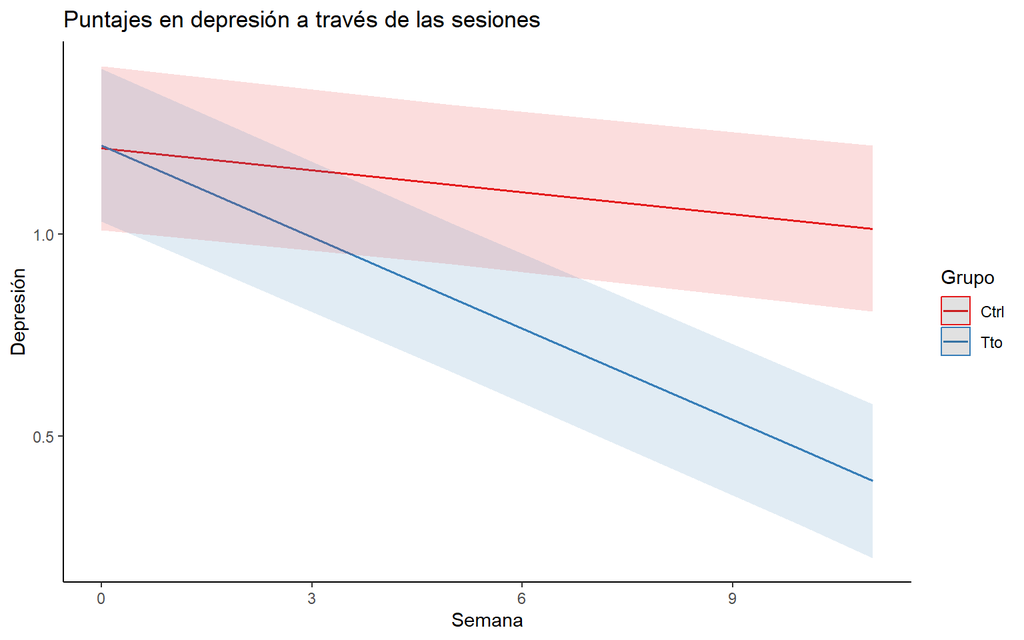

```r
plot_model(BDIModel, type = "pred", terms = c("Week", "Condition")) +
  theme(axis.line = element_line(colour = "black"),
        panel.grid.major = element_blank(),
        panel.grid.minor = element_blank(),
        panel.border = element_blank(),
        panel.background = element_blank()) +
  ggtitle("Puntajes en depresión a través de las sesiones") +
  ylab("Depresión") +
  xlab("Semana") +
  labs(colour = "Grupo")
```

> The model comparison using maximum likelihood between a model with interaction between weeks and group as fixed factors and random intercepts for participants and items, compared to a model that only included random effects, was significant (χ²(3) = 289.51, p < .001). The model that only included random effects showed higher fit indices (AIC = 6793.2, BIC = 6817.0) compared to the model with fixed factors (AIC = 6509.7, BIC = 6551.4), suggesting that the full model provides a better fit to the data.  
> In the model including fixed effects, using Satterthwaite’s t estimate, no significant differences were observed between the groups at the start of the study (b = 0.01, 95% CI [-0.24, 0.26], p = 0.957), indicating that both groups started with similar levels of depression. However, a significant interaction between time and condition was observed (b = -0.06, 95% CI [-0.07, -0.04], p < .001), indicating that the treatment group showed a more pronounced decrease in depression levels over time compared to the control group.  
> In this model, 27% of the variance in the scores is explained by differences between participants and items (ICC = 0.27). 9.4% of the variance is explained by the fixed effects, and 34% of the total variance is explained by the full model.  
> Finally, the analysis of adjusted marginal means for week 10 showed a significant difference between the control and treatment groups, where the treatment group had significantly lower depression levels at the end of the study (t(50.9) = 4.44, 95% CI [0.32, 0.81], p < .001).

# Anxiety

## Base model

We run the base model, which we will compare with the model of interest. This model only includes random effects.

```r
BAIbase <- lmer(rating ~ (1|ID) + (1|item), data = BAIlong)
```

## Model with fixed effects interaction

```r
BAIModel <- lmer(rating ~ Week * Condition + (1|ID) + (1|item), data = BAIlong)
summary(BAIModel)
```

```
## Linear mixed model fit by REML. t-tests use Satterthwaite's method [
## lmerModLmerTest]
## Formula: rating ~ Week * Condition + (1 | ID) + (1 | item)
##    Data: BAIlong
##
## REML criterion at convergence: 6266.6
##
## Scaled residuals:
##     Min      1Q  Median      3Q     Max
## -2.9525 -0.6877 -0.1293  0.5909  3.4655
##
## Random effects:
##  Groups   Name        Variance Std.Dev.
##  ID       (Intercept) 0.2098   0.4580
##  item     (Intercept) 0.1033   0.3214
##  Residual             0.4908   0.7006
## Number of obs: 2835, groups:  ID, 46; item, 21
##
## Fixed effects:
##                      Estimate  Std. Error          df t value        Pr(>|t|)
## (Intercept)          1.025070    0.126121   67.672351   8.128 0.0000000000133
## Week                -0.014286    0.004834 2767.138961  -2.955         0.00315
## ConditionTto        -0.185822    0.141948   49.119179  -1.309         0.19660
## Week:ConditionTto   -0.033060    0.006427 2767.226812  -5.144 0.0000002875544
##
## (Intercept)       ***
## Week              **
## ConditionTto
## Week:ConditionTto ***
## ---
## Signif. codes:  0 '***' 0.001 '**' 0.01 '*' 0.05 '.' 0.1 ' ' 1
##
## Correlation of Fixed Effects:
##             (Intr) Week   CndtnT
## Week        -0.192
## ConditionTt -0.614  0.170
## Wek:CndtnTt  0.144 -0.752 -0.228
```

> **Random effects:** On average, the anxiety scores of a typical participant vary by ±0.46 points from the overall mean, reflecting individual differences in anxiety levels, regardless of the item or week. Additionally, the scores of a typical item vary by ±0.32 points from the overall mean, suggesting that some items consistently receive higher or lower scores regarding anxiety.  
> **Fixed effects:** The main effect of the treatment condition is not statistically significant (Estimate = -0.1858, p = 0.197), indicating that at the start of the study (week 0), there are no significant differences in anxiety levels between the treatment and control groups. Both groups start with similar anxiety levels, which is crucial for assessing the effects of the treatment over time.  
> **Interaction:** The interaction between week and treatment condition is significant (Estimate = -0.0331, p < 0.001). This suggests that the reduction in anxiety levels over time is more pronounced in the treatment group compared to the control group. In other words, participants in the treatment group experience a greater decrease in anxiety symptoms as time progresses.

## Group comparison at the end of the treatment

```r
emBAI_week10 <- emmeans(BAIModel, pairwise ~ Condition | Week, at = list(Week = 10))
summary(emBAI_week10)
```

```
## $emmeans
## Week = 10:
##  Condition emmean    SE   df lower.CL upper.CL
##  Ctrl       0.882 0.126 67.5    0.631    1.134
##  Tto        0.366 0.119 65.3    0.129    0.603
##
## Degrees-of-freedom method: kenward-roger
## Confidence level used: 0.95
##
## $contrasts
## Week = 10:
##  contrast   estimate    SE   df t.ratio p.value
##  Ctrl - Tto    0.516 0.142 48.9   3.640  0.0007
##
## Degrees-of-freedom method: kenward-roger
```

> The analysis using adjusted marginal means (emmeans) for week 10 reveals a significant difference between the control and treatment groups in terms of anxiety levels. In week 10, the control group has an adjusted marginal mean of 0.88, while the treatment group has a mean of 0.37. This difference of 0.52 points is statistically significant (p < 0.001), suggesting that participants in the treatment group have significantly lower anxiety scores at the end of the treatment compared to those in the control group.

## Model comparison

```r
anova(BAIbase, BAIModel)
```

```
## Data: BAIlong
## Models:
## BAIbase: rating ~ (1 | ID) + (1 | item)
## BAIModel: rating ~ Week * Condition + (1 | ID) + (1 | item)
##          npar    AIC    BIC  logLik deviance  Chisq Df            Pr(>Chisq)
## BAIbase     4 6388.7 6412.5 -3190.4   6380.7
## BAIModel    7 6257.7 6299.3 -3121.8   6243.7 137.04  3 < 0.00000000000000022
##
## BAIbase
## BAIModel ***
## ---
## Signif. codes:  0 '***' 0.001 '**' 0.01 '*' 0.05 '.' 0.1 ' ' 1
```

> The AIC and BIC values are lower in the full model (BAIModel) compared to the base model (BAIbase), indicating a better fit of the full model when considering the penalty for complexity. The full model, which includes the fixed effects of week (Week) and treatment condition (Condition), as well as their interaction, provides a significantly better fit to the data compared to the base model, which only includes random effects. The difference in fit is significant (χ²(3) = 137.04, p < 0.001), suggesting that the inclusion of the fixed effects substantially improves the model’s ability to explain the variability in anxiety scores (BAI) over time and between conditions.

## Results add report

```r
tab_model(BAIModel)
```

|  | rating |  |  |
| --- | --- | --- | --- |
| Predictors | Estimates | CI | p |
| (Intercept) | 1.03 | 0.78 – 1.27 | **<0.001** |
| Week | -0.01 | -0.02 – -0.00 | **0.003** |
| Condition [Tto] | -0.19 | -0.46 – 0.09 | 0.191 |
| Week × Condition [Tto] | -0.03 | -0.05 – -0.02 | **<0.001** |
| Random Effects |  |  |  |
| σ<sup>2</sup> | 0.49 |  |  |
| τ<sub>00</sub> <sub>ID</sub> | 0.21 |  |  |
| τ<sub>00</sub> <sub>item</sub> | 0.10 |  |  |
| ICC | 0.39 |  |  |
| N <sub>ID</sub> | 46 |  |  |
| N <sub>item</sub> | 21 |  |  |
| Observations | 2835 |  |  |
| Marginal R<sup>2</sup> / Conditional R<sup>2</sup> | 0.063 / 0.428 |  |  |

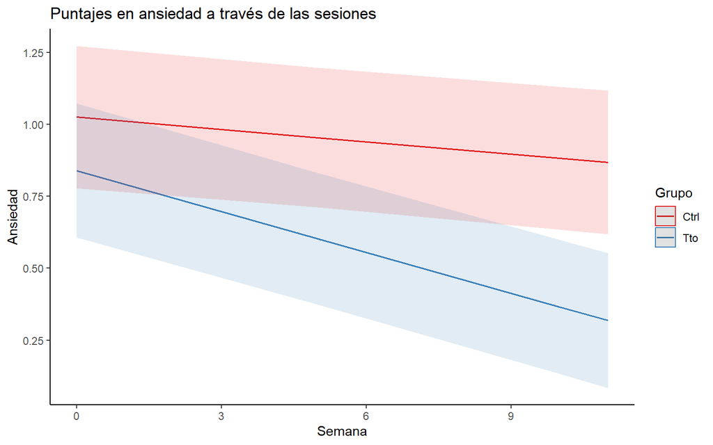

```r
plot_model(BAIModel, type = "pred", terms = c("Week", "Condition")) +
  theme(axis.line = element_line(colour = "black"),
        panel.grid.major = element_blank(),
        panel.grid.minor = element_blank(),
        panel.border = element_blank(),
        panel.background = element_blank()) +
  ggtitle("Puntajes en ansiedad a través de las sesiones") +
  ylab("Ansiedad") +
  xlab("Semana") +
  labs(colour = "Grupo")
```